# 懒人的胡言乱语

Posted on 2021-03-01

#### 国际惯例，常用库引用

```python
import tensorflow as tf
import numpy as np
import os
from tensorflow import keras
from tensorflow.keras import layers, Sequential,models
import matplotlib.pyplot as plt
```

#### 因为我们要做标签归类 tf 搞了这些封装 ， 使用起来会更加容易

```python
mnist = tf.keras.datasets.mnist
# os.environ['KMP_DUPLICATE_LIB_OK']='True'
```

#### 这里是TensorFlow 官网的 Hello World 还要继续讲这个的原因是因为这样的流程让开发者更加清晰

```python
(x_train, y_train),(x_test, y_test) = mnist.load_data()

x_train, x_test = x_train / 255.0, x_test / 255.0
# x_train = x_train / 255.0
# x_test = x_test / 255.0
```

```
Downloading data from https://storage.googleapis.com/tensorflow/tf-keras-datasets/mnist.npz
```

```python
print(x_train.shape,y_train.shape)
```

```
(60000, 28, 28) (60000,)
```

##### 60000 *(28* 28 * 1) ------> 60000 对应关系 60000 张图片，有60000个 label （0 - 9） 共10 种

##### 建立训练模型

```python
model = Sequential(name = "mnist_model")
```

```python
flatten_data = layers.Flatten(input_shape=(28, 28))
model.add(flatten_data)
```

```python
layer_1 = layers.Dense(128,activation='relu')
model.add(layer_1)
```

```python
layer_2 = layers.Dropout(0.2)
model.add(layer_2)
```

```python
layer_3 = layers.Dense(10, activation='softmax')    # y    0 -- 9
model.add(layer_3)
```

#### 上面就是建立模型的过程，可以暂时简单的理解为一层一层的添加 想象一下多层汉堡 🍔 这个想象让我都饿了

#### 虽然上面这种写法没任何问题，但是似乎整体上来看就有点凌乱，毕竟模块的方式大家都很喜欢，但是懒人比如新手或者说我 对上面的方式也没什么异议，但是总觉得会有更好的方法 , 所以既然有更好的方法，下次我就用稍微好点的方式来做

#### 下面就很通用了， 拿到模型然后进行编译，丢进去 optimizer， loss， metrics 然后调用就是了 模式就是这样的，参数可以根据自己需要来搞

```python
model.summary()
```

```
Model: "mnist_model"
_________________________________________________________________
Layer (type)                 Output Shape              Param #
=================================================================
flatten (Flatten)            (None, 784)               0
_________________________________________________________________
dense (Dense)                (None, 128)               100480
_________________________________________________________________
dropout (Dropout)            (None, 128)               0
_________________________________________________________________
dense_1 (Dense)              (None, 10)                1290
=================================================================
Total params: 101,770
Trainable params: 101,770
Non-trainable params: 0
_________________________________________________________________
```

```python
model.compile(optimizer='adam',
              loss='sparse_categorical_crossentropy',
              metrics=['accuracy'])
```

#### 这里虽然简短确是高效，如果想要使用tensorboard 来观察loss 变化，这里可以加上callbacks

```python
model.fit(x_train, y_train, epochs=2)
```

```
Train on 60000 samples
```

```
<tensorflow.python.keras.callbacks.History at 0x65fab1dd0>
```

#### 比如经过上面的训练，我们的模型就基本已经好了，但是如何验证我们的模型符合我们的设计要求呢 ？ Tensorflow 给出了下面的方式

```python
test_loss, test_accuracy = model.evaluate(x_test, y_test, verbose=0)
print(test_loss,test_accuracy)
```

```
0.09898662575222551 0.9714
```

#### x_test, y_test 他们的出处就得考虑下了 ， tensorflow 在使用 mnist 的时候 load_data 这个方法做了处理，前边两个值用来训练，后面两个值用来测试

#### 这么一看上面的内容简单多了， 而且是图片标签分类， 想象一下，如果自己下载一堆猫和狗的图片，然后用这个方法去做区分会有多么简单

```python
#  获取预测的结果
predict_result = model.predict(x_train)
np.argmax(predict_result[10])
```

```
3
```

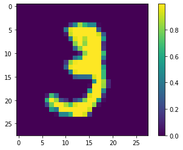

```python
# 画图！ 就是要证据！
plt.figure()
plt.imshow(x_train[10])
plt.colorbar()
plt.grid(False)
plt.show()
```

#### 呐！预测值，还有图片，这果然是 3

[figure not shown]